# Pandas_Data_Aanlysis_Sales_Data_Completed

```python
import pandas as pd
```

```python
file_path = "C:\\Work\\Python\\Pandas\\Data\\Sales_Data\\"
```

```python
file_path
```

```
'C:\\Work\\Python\\Pandas\\Data\\Sales_Data\\'
```

```python
file_name = 'Sales_January_2019.csv'
```

```python
full_path = file_path + file_name
```

```python
full_path
```

```
'C:\\Work\\Python\\Pandas\\Data\\Sales_Data\\Sales_January_2019.csv'
```

```python
pd.read_csv(full_path)
```

|  | Order ID | Product | Quantity Ordered | Price Each | Order Date | Purchase Address |
| --- | --- | --- | --- | --- | --- | --- |
| 0 | 141234 | iPhone | 1 | 700 | 01/22/19 21:25 | 944 Walnut St, Boston, MA 02215 |
| 1 | 141235 | Lightning Charging Cable | 1 | 14.95 | 01/28/19 14:15 | 185 Maple St, Portland, OR 97035 |
| 2 | 141236 | Wired Headphones | 2 | 11.99 | 01/17/19 13:33 | 538 Adams St, San Francisco, CA 94016 |
| 3 | 141237 | 27in FHD Monitor | 1 | 149.99 | 01/05/19 20:33 | 738 10th St, Los Angeles, CA 90001 |
| 4 | 141238 | Wired Headphones | 1 | 11.99 | 01/25/19 11:59 | 387 10th St, Austin, TX 73301 |
| ... | ... | ... | ... | ... | ... | ... |
| 9718 | 150497 | 20in Monitor | 1 | 109.99 | 01/26/19 19:09 | 95 8th St, Dallas, TX 75001 |
| 9719 | 150498 | 27in FHD Monitor | 1 | 149.99 | 01/10/19 22:58 | 403 7th St, San Francisco, CA 94016 |
| 9720 | 150499 | ThinkPad Laptop | 1 | 999.99 | 01/21/19 14:31 | 214 Main St, Portland, OR 97035 |
| 9721 | 150500 | AAA Batteries (4-pack) | 2 | 2.99 | 01/15/19 14:21 | 810 2nd St, Los Angeles, CA 90001 |
| 9722 | 150501 | Google Phone | 1 | 600 | 01/13/19 16:43 | 428 Cedar St, Boston, MA 02215 |

9723 rows × 6 columns

```python
import os

final_df = pd.DataFrame()
for file_name in  os.listdir(file_path):
    full_path = f'{file_path}{file_name}'
    df_temp = pd.read_csv(full_path)
    df_temp['src_file'] = file_name
    final_df = pd.concat([final_df, df_temp])
    print(f'The size of final df is {final_df.shape}. The size of temp df is {df_temp.shape}')
```

```
The size of final df is (18383, 7). The size of temp df is (18383, 7)
The size of final df is (30394, 7). The size of temp df is (12011, 7)
The size of final df is (55511, 7). The size of temp df is (25117, 7)
The size of final df is (67547, 7). The size of temp df is (12036, 7)
The size of final df is (77270, 7). The size of temp df is (9723, 7)
The size of final df is (91641, 7). The size of temp df is (14371, 7)
The size of final df is (105263, 7). The size of temp df is (13622, 7)
The size of final df is (120489, 7). The size of temp df is (15226, 7)
The size of final df is (137124, 7). The size of temp df is (16635, 7)
The size of final df is (154785, 7). The size of temp df is (17661, 7)
The size of final df is (175164, 7). The size of temp df is (20379, 7)
The size of final df is (186850, 7). The size of temp df is (11686, 7)
```

```python
import os
```

### I read source data coming from different sources and collated the data before transformations were performed to clean the data in the accepted format

```python
# the listdir function will list all the files and folders under a folder
file_path = "C:\\Work\\Python\\Pandas\\Data\\Sales_Data\\"
final_df = pd.DataFrame()
print('The shape of the final_df =',final_df.shape)
for file_name in os.listdir(file_path):
    full_path = file_path+file_name
    df = pd.read_csv(full_path)
    final_df = pd.concat([final_df, df])
    print(full_path, df.shape, final_df.shape)

print('I am out of the for loop')
print(final_df.shape)
```

```
The shape of the final_df = (0, 0)
C:\Work\Python\Pandas\Data\Sales_Data\Sales_April_2019.csv (18383, 6) (18383, 6)
C:\Work\Python\Pandas\Data\Sales_Data\Sales_August_2019.csv (12011, 6) (30394, 6)
C:\Work\Python\Pandas\Data\Sales_Data\Sales_December_2019.csv (25117, 6) (55511, 6)
C:\Work\Python\Pandas\Data\Sales_Data\Sales_February_2019.csv (12036, 6) (67547, 6)
C:\Work\Python\Pandas\Data\Sales_Data\Sales_January_2019.csv (9723, 6) (77270, 6)
C:\Work\Python\Pandas\Data\Sales_Data\Sales_July_2019.csv (14371, 6) (91641, 6)
C:\Work\Python\Pandas\Data\Sales_Data\Sales_June_2019.csv (13622, 6) (105263, 6)
C:\Work\Python\Pandas\Data\Sales_Data\Sales_March_2019.csv (15226, 6) (120489, 6)
C:\Work\Python\Pandas\Data\Sales_Data\Sales_May_2019.csv (16635, 6) (137124, 6)
C:\Work\Python\Pandas\Data\Sales_Data\Sales_November_2019.csv (17661, 6) (154785, 6)
C:\Work\Python\Pandas\Data\Sales_Data\Sales_October_2019.csv (20379, 6) (175164, 6)
C:\Work\Python\Pandas\Data\Sales_Data\Sales_September_2019.csv (11686, 6) (186850, 6)
I am out of the for loop
(186850, 6)
```

```python
file_name_1 = 'C:\Work\Python\Pandas\Data\Sales_Data\Sales_April_2019.csv'
file_name_2 = 'C:\Work\Python\Pandas\Data\Sales_Data\Sales_August_2019.csv'
file_name_3 = '\Work\Python\Pandas\Data\Sales_Data\Sales_September_2019.csv'
df_1 = pd.read_csv(file_name_1)
df_2 = pd.read_csv(file_name_2)
df_3 = pd.read_csv(file_name_3)
print(df_1.shape)
print(df_2.shape)
print(df_3.shape)
```

```
(18383, 6)
(12011, 6)
(11686, 6)
```

```python
# concatinates multiple dataframes into a single dataframe
pd.concat([df_1, df_2, df_3]).shape
```

```
(42080, 6)
```

```python
# once the final_df has data from all the files we will start the process of cleaning the data
```

### once the data is ingested, i cleaned the data using the Pandas library

```python
final_df.isna().sum(axis=0)
```

```
Order ID            545
Product             545
Quantity Ordered    545
Price Each          545
Order Date          545
Purchase Address    545
dtype: int64
```

### Step 1 > Data cleaning step 1. Remove NULLs.

```python
# I will remove the null values such that I will only select those rows where 'Order ID' is not null
final_df = final_df.loc[~(final_df['Order ID'].isnull()), :]
```

```python
final_df.isna().sum(axis=0)
```

```
Order ID            0
Product             0
Quantity Ordered    0
Price Each          0
Order Date          0
Purchase Address    0
dtype: int64
```

```python
final_df.dtypes
```

```
Order ID            object
Product             object
Quantity Ordered    object
Price Each          object
Order Date          object
Purchase Address    object
dtype: object
```

```python
final_df.head()
```

|  | Order ID | Product | Quantity Ordered | Price Each | Order Date | Purchase Address |
| --- | --- | --- | --- | --- | --- | --- |
| 0 | 176558 | USB-C Charging Cable | 2 | 11.95 | 04/19/19 08:46 | 917 1st St, Dallas, TX 75001 |
| 2 | 176559 | Bose SoundSport Headphones | 1 | 99.99 | 04/07/19 22:30 | 682 Chestnut St, Boston, MA 02215 |
| 3 | 176560 | Google Phone | 1 | 600 | 04/12/19 14:38 | 669 Spruce St, Los Angeles, CA 90001 |
| 4 | 176560 | Wired Headphones | 1 | 11.99 | 04/12/19 14:38 | 669 Spruce St, Los Angeles, CA 90001 |
| 5 | 176561 | Wired Headphones | 1 | 11.99 | 04/30/19 09:27 | 333 8th St, Los Angeles, CA 90001 |

```python
final_df['Quantity Ordered'].astype(int)
```

[output not shown]

```python
int('Quantity Ordered')
```

```
---------------------------------------------------------------------------
ValueError                                Traceback (most recent call last)
~\AppData\Local\Temp\ipykernel_21184\3778909084.py in <module>
----> 1 int('Quantity Ordered')

ValueError: invalid literal for int() with base 10: 'Quantity Ordered'
```

### How do I find out rows where the column 'Quantity Ordered' has the value 'Quantity Ordered'?

## The sales data is generated from a COGNOS report.

### the data came to us, Data Analyst, from the cognos report

### we get the data dump, which is our source from the data engneers

```python
final_df = final_df.loc[(final_df['Quantity Ordered']!='Quantity Ordered'), :]
```

```python
final_df.head()
```

|  | Order ID | Product | Quantity Ordered | Price Each | Order Date | Purchase Address |
| --- | --- | --- | --- | --- | --- | --- |
| 0 | 176558 | USB-C Charging Cable | 2 | 11.95 | 04/19/19 08:46 | 917 1st St, Dallas, TX 75001 |
| 2 | 176559 | Bose SoundSport Headphones | 1 | 99.99 | 04/07/19 22:30 | 682 Chestnut St, Boston, MA 02215 |
| 3 | 176560 | Google Phone | 1 | 600 | 04/12/19 14:38 | 669 Spruce St, Los Angeles, CA 90001 |
| 4 | 176560 | Wired Headphones | 1 | 11.99 | 04/12/19 14:38 | 669 Spruce St, Los Angeles, CA 90001 |
| 5 | 176561 | Wired Headphones | 1 | 11.99 | 04/30/19 09:27 | 333 8th St, Los Angeles, CA 90001 |

```python
final_df['Quantity Ordered'] = final_df['Quantity Ordered'].astype(int)
```

### Step 3 >> Convert all the columns to the correct Data Type.

### Initially the columns were all of type Object.

### as part of Data Cleaning Activity, I converted the columns to the correct Data Types.

### example , I converted column Quantity Ordered to type int.

```python
final_df.dtypes
```

```
Order ID            object
Product             object
Quantity Ordered     int32
Price Each          object
Order Date          object
Purchase Address    object
dtype: object
```

```python
final_df.head()
```

|  | Order ID | Product | Quantity Ordered | Price Each | Order Date | Purchase Address |
| --- | --- | --- | --- | --- | --- | --- |
| 0 | 176558 | USB-C Charging Cable | 2 | 11.95 | 04/19/19 08:46 | 917 1st St, Dallas, TX 75001 |
| 2 | 176559 | Bose SoundSport Headphones | 1 | 99.99 | 04/07/19 22:30 | 682 Chestnut St, Boston, MA 02215 |
| 3 | 176560 | Google Phone | 1 | 600 | 04/12/19 14:38 | 669 Spruce St, Los Angeles, CA 90001 |
| 4 | 176560 | Wired Headphones | 1 | 11.99 | 04/12/19 14:38 | 669 Spruce St, Los Angeles, CA 90001 |
| 5 | 176561 | Wired Headphones | 1 | 11.99 | 04/30/19 09:27 | 333 8th St, Los Angeles, CA 90001 |

```python
### source to target mapping
### schema implemtation ( provide the right datatype to the right column )
### based on the requirement document provided by the User. (Functional Doc, FSD)
### FUNCTIONAL Specification Document.
### FSD was provided as an EXCEL by the stakeholder
```

```python
final_df['Price Each'] = final_df['Price Each'].astype(float)
final_df['Order ID'] = final_df['Order ID'].astype(int)
```

```python
final_df.dtypes
```

```
Order ID              int32
Product              object
Quantity Ordered      int32
Price Each          float64
Order Date           object
Purchase Address     object
dtype: object
```

```python
final_df.head()
```

|  | Order ID | Product | Quantity Ordered | Price Each | Order Date | Purchase Address |
| --- | --- | --- | --- | --- | --- | --- |
| 0 | 176558 | USB-C Charging Cable | 2 | 11.95 | 04/19/19 08:46 | 917 1st St, Dallas, TX 75001 |
| 2 | 176559 | Bose SoundSport Headphones | 1 | 99.99 | 04/07/19 22:30 | 682 Chestnut St, Boston, MA 02215 |
| 3 | 176560 | Google Phone | 1 | 600.00 | 04/12/19 14:38 | 669 Spruce St, Los Angeles, CA 90001 |
| 4 | 176560 | Wired Headphones | 1 | 11.99 | 04/12/19 14:38 | 669 Spruce St, Los Angeles, CA 90001 |
| 5 | 176561 | Wired Headphones | 1 | 11.99 | 04/30/19 09:27 | 333 8th St, Los Angeles, CA 90001 |

### Transformation - clean up the column names

### FSD provided by the holder.

### final column names are also provided by the stakeholder as part of FSD document

### This process is called as SOURCE to TARGET Mapping.

```python
final_df.columns = final_df.columns.str.lower().str.replace(' ', '_')
```

```python
final_df.head()
```

|  | order_id | product | quantity_ordered | price_each | order_date | purchase_address |
| --- | --- | --- | --- | --- | --- | --- |
| 0 | 176558 | USB-C Charging Cable | 2 | 11.95 | 04/19/19 08:46 | 917 1st St, Dallas, TX 75001 |
| 2 | 176559 | Bose SoundSport Headphones | 1 | 99.99 | 04/07/19 22:30 | 682 Chestnut St, Boston, MA 02215 |
| 3 | 176560 | Google Phone | 1 | 600.00 | 04/12/19 14:38 | 669 Spruce St, Los Angeles, CA 90001 |
| 4 | 176560 | Wired Headphones | 1 | 11.99 | 04/12/19 14:38 | 669 Spruce St, Los Angeles, CA 90001 |
| 5 | 176561 | Wired Headphones | 1 | 11.99 | 04/30/19 09:27 | 333 8th St, Los Angeles, CA 90001 |

```python
### Transformations - Feature Engineering
```

```python
## we want to find the sales by State
```

```python
def get_state(address):
    state_zip =  address.split(', ')[-1]
    state_name = state_zip.split()[0].strip()
    return state_name
```

```python
get_state('917 1st St, Dallas, TX 75001')
```

```
'TX'
```

```python
### created derived columns to perform analysis
final_df['state_name'] = final_df['purchase_address'].apply(get_state)
```

```python
final_df.head()
```

|  | order_id | product | quantity_ordered | price_each | order_date | purchase_address | state_name |
| --- | --- | --- | --- | --- | --- | --- | --- |
| 0 | 176558 | USB-C Charging Cable | 2 | 11.95 | 04/19/19 08:46 | 917 1st St, Dallas, TX 75001 | TX |
| 2 | 176559 | Bose SoundSport Headphones | 1 | 99.99 | 04/07/19 22:30 | 682 Chestnut St, Boston, MA 02215 | MA |
| 3 | 176560 | Google Phone | 1 | 600.00 | 04/12/19 14:38 | 669 Spruce St, Los Angeles, CA 90001 | CA |
| 4 | 176560 | Wired Headphones | 1 | 11.99 | 04/12/19 14:38 | 669 Spruce St, Los Angeles, CA 90001 | CA |
| 5 | 176561 | Wired Headphones | 1 | 11.99 | 04/30/19 09:27 | 333 8th St, Los Angeles, CA 90001 | CA |

```python
final_df['final_bill'] = final_df['quantity_ordered'] * final_df['price_each']
```

```python
## we are creating derived columns so that we can do the analysis
## find the total sales by state?
final_df.head()
```

|  | order_id | product | quantity_ordered | price_each | order_date | purchase_address | state_name | final_bill |
| --- | --- | --- | --- | --- | --- | --- | --- | --- |
| 0 | 176558 | USB-C Charging Cable | 2 | 11.95 | 04/19/19 08:46 | 917 1st St, Dallas, TX 75001 | TX | 23.90 |
| 2 | 176559 | Bose SoundSport Headphones | 1 | 99.99 | 04/07/19 22:30 | 682 Chestnut St, Boston, MA 02215 | MA | 99.99 |
| 3 | 176560 | Google Phone | 1 | 600.00 | 04/12/19 14:38 | 669 Spruce St, Los Angeles, CA 90001 | CA | 600.00 |
| 4 | 176560 | Wired Headphones | 1 | 11.99 | 04/12/19 14:38 | 669 Spruce St, Los Angeles, CA 90001 | CA | 11.99 |
| 5 | 176561 | Wired Headphones | 1 | 11.99 | 04/30/19 09:27 | 333 8th St, Los Angeles, CA 90001 | CA | 11.99 |

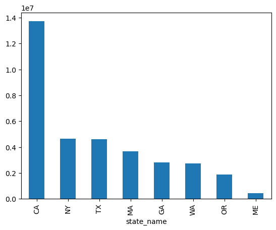

```python
import matplotlib.pyplot as plt

final_df.groupby(['state_name'])['final_bill'].sum().sort_values(ascending=False).plot(kind='bar')
plt.show()
```

```python
## find the total orders by state?
```

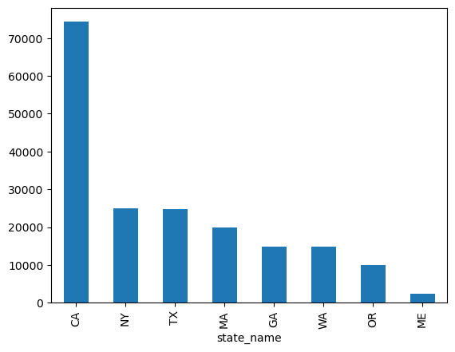

```python
final_df.groupby(['state_name'])['order_id'].count().sort_values(ascending=False).plot(kind="bar")
plt.show()
```

```python
# total sales by city.
def get_city(address):
    city_name  =  address.split(', ')[1]
    return city_name.strip()

get_state('917 1st St, Dallas, TX 75001')
```

```
'TX'
```

```python
final_df['City'] = \
final_df['purchase_address'].apply(lambda address: address.split(', ')[1].strip())
```

```python
final_df.head()
```

|  | order_id | product | quantity_ordered | price_each | order_date | purchase_address | state_name | final_bill | City |
| --- | --- | --- | --- | --- | --- | --- | --- | --- | --- |
| 0 | 176558 | USB-C Charging Cable | 2 | 11.95 | 04/19/19 08:46 | 917 1st St, Dallas, TX 75001 | TX | 23.90 | Dallas |
| 2 | 176559 | Bose SoundSport Headphones | 1 | 99.99 | 04/07/19 22:30 | 682 Chestnut St, Boston, MA 02215 | MA | 99.99 | Boston |
| 3 | 176560 | Google Phone | 1 | 600.00 | 04/12/19 14:38 | 669 Spruce St, Los Angeles, CA 90001 | CA | 600.00 | Los Angeles |
| 4 | 176560 | Wired Headphones | 1 | 11.99 | 04/12/19 14:38 | 669 Spruce St, Los Angeles, CA 90001 | CA | 11.99 | Los Angeles |
| 5 | 176561 | Wired Headphones | 1 | 11.99 | 04/30/19 09:27 | 333 8th St, Los Angeles, CA 90001 | CA | 11.99 | Los Angeles |

```python
final_df.groupby(['City'])['final_bill'].sum().sort_values(ascending=False)
```

```
City
San Francisco    8262203.91
Los Angeles      5452570.80
New York City    4664317.43
Boston           3661642.01
Atlanta          2795498.58
Dallas           2767975.40
Seattle          2747755.48
Portland         2320490.61
Austin           1819581.75
Name: final_bill, dtype: float64
```

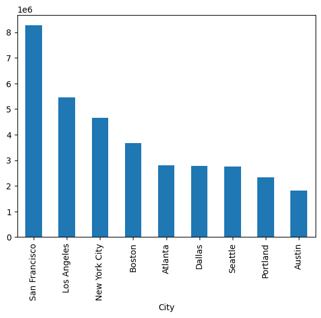

```python
final_df.groupby(['City'])['final_bill'].sum().sort_values(ascending=False).plot(kind="bar")
```

```python
final_df.groupby(['City', 'state_name'])['order_id'].count()
```

```
City           state_name
Atlanta        GA            14881
Austin         TX             9905
Boston         MA            19934
Dallas         TX            14820
Los Angeles    CA            29605
New York City  NY            24876
Portland       ME             2455
               OR            10010
San Francisco  CA            44732
Seattle        WA            14732
Name: order_id, dtype: int64
```

```python
city_state_sales = final_df.groupby(['City', 'state_name'])['order_id'].count()
```

```python
type(city_state_sales)
```

```
pandas.core.series.Series
```

```python
pd.DataFrame(city_state_sales).index
```

```
MultiIndex([(      'Atlanta', 'GA'),
            (       'Austin', 'TX'),
            (       'Boston', 'MA'),
            (       'Dallas', 'TX'),
            (  'Los Angeles', 'CA'),
            ('New York City', 'NY'),
            (     'Portland', 'ME'),
            (     'Portland', 'OR'),
            ('San Francisco', 'CA'),
            (      'Seattle', 'WA')],
           names=['City', 'state_name'])
```

```python
pd.DataFrame(city_state_sales).loc[('Austin', 'TX'), :]
```

```
order_id    9905
Name: (Austin, TX), dtype: int64
```

```python
pd.DataFrame(city_state_sales).loc[[('Atlanta', 'GA'),
                                   ('Austin', 'TX')], ['order_id']]
```

| City | state_name | order_id |
| --- | --- | --- |
| Atlanta | GA | 14881 |
| Austin | TX | 9905 |

```python
pd.DataFrame(city_state_sales).reset_index()
# OR = Oregon
# ME - Maine
```

|  | City | state_name | order_id |
| --- | --- | --- | --- |
| 0 | Atlanta | GA | 14881 |
| 1 | Austin | TX | 9905 |
| 2 | Boston | MA | 19934 |
| 3 | Dallas | TX | 14820 |
| 4 | Los Angeles | CA | 29605 |
| 5 | New York City | NY | 24876 |
| 6 | Portland | ME | 2455 |
| 7 | Portland | OR | 10010 |
| 8 | San Francisco | CA | 44732 |
| 9 | Seattle | WA | 14732 |

```python
series_value = final_df.groupby(['City', 'state_name'])['order_id'].count()
```

```python
series_value.index
```

```
MultiIndex([(      'Atlanta', 'GA'),
            (       'Austin', 'TX'),
            (       'Boston', 'MA'),
            (       'Dallas', 'TX'),
            (  'Los Angeles', 'CA'),
            ('New York City', 'NY'),
            (     'Portland', 'ME'),
            (     'Portland', 'OR'),
            ('San Francisco', 'CA'),
            (      'Seattle', 'WA')],
           names=['City', 'state_name'])
```

```python
series_value[(      'Atlanta', 'GA')]
```

```
14881
```

```python
series_value[('Dallas', 'TX')]
```

```
14820
```

```python
series_value[(      'Seattle', 'WA')]
```

```
14732
```

```python
pd.DataFrame(series_value).reset_index()
```

|  | City | state_name | order_id |
| --- | --- | --- | --- |
| 0 | Atlanta | GA | 14881 |
| 1 | Austin | TX | 9905 |
| 2 | Boston | MA | 19934 |
| 3 | Dallas | TX | 14820 |
| 4 | Los Angeles | CA | 29605 |
| 5 | New York City | NY | 24876 |
| 6 | Portland | ME | 2455 |
| 7 | Portland | OR | 10010 |
| 8 | San Francisco | CA | 44732 |
| 9 | Seattle | WA | 14732 |

```python
# Sometimes the level of granularity provided by the stakeholder is not very clear
# I used Exploratory Data Analysis to find the right levels of Granularity to perform aggregations
```

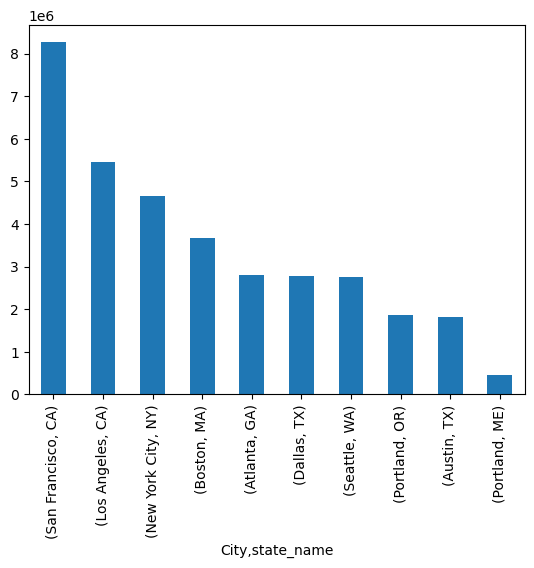

```python
final_df.groupby(['City',
                  'state_name'])['final_bill'].sum().sort_values(ascending=False) \
.plot(kind="bar")
```

```python
final_df.head()
```

|  | order_id | product | quantity_ordered | price_each | order_date | purchase_address | state_name | final_bill | City |
| --- | --- | --- | --- | --- | --- | --- | --- | --- | --- |
| 0 | 176558 | USB-C Charging Cable | 2 | 11.95 | 04/19/19 08:46 | 917 1st St, Dallas, TX 75001 | TX | 23.90 | Dallas |
| 2 | 176559 | Bose SoundSport Headphones | 1 | 99.99 | 04/07/19 22:30 | 682 Chestnut St, Boston, MA 02215 | MA | 99.99 | Boston |
| 3 | 176560 | Google Phone | 1 | 600.00 | 04/12/19 14:38 | 669 Spruce St, Los Angeles, CA 90001 | CA | 600.00 | Los Angeles |
| 4 | 176560 | Wired Headphones | 1 | 11.99 | 04/12/19 14:38 | 669 Spruce St, Los Angeles, CA 90001 | CA | 11.99 | Los Angeles |
| 5 | 176561 | Wired Headphones | 1 | 11.99 | 04/30/19 09:27 | 333 8th St, Los Angeles, CA 90001 | CA | 11.99 | Los Angeles |

```python
final_df.dtypes
```

```
order_id              int32
product              object
quantity_ordered      int32
price_each          float64
order_date           object
purchase_address     object
state_name           object
final_bill          float64
City                 object
dtype: object
```

```python
final_df['order_date'] = pd.to_datetime(final_df['order_date'], format='%m/%d/%y %H:%M')
```

```python
pd.to_datetime('20240501', format='%Y%m%d')
```

```
Timestamp('2024-05-01 00:00:00')
```

```python
final_df['order_date'] = pd.to_datetime(final_df['order_date'], format = '%m/%d/%y %H:%M')
```

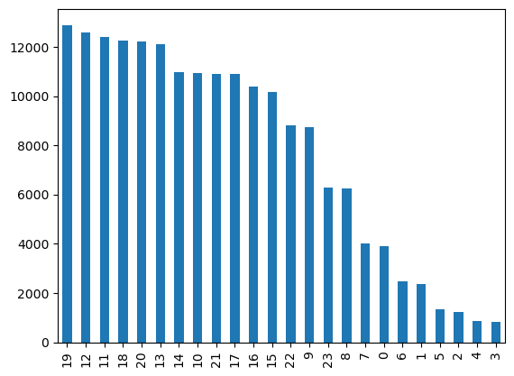

```python
final_df['order_date'].dt.hour.value_counts(dropna=False).plot(kind='bar')
```

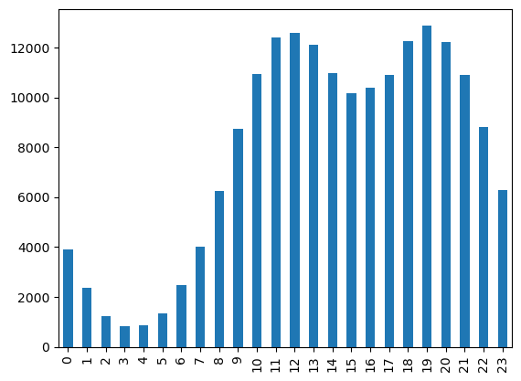

```python
final_df['order_date'].dt.hour.value_counts(dropna=False).sort_index().plot(kind='bar')
```

```python
final_df.isna().sum(axis=0)
```

```
order_id            0
product             0
quantity_ordered    0
price_each          0
order_date          0
purchase_address    0
state_name          0
final_bill          0
City                0
dtype: int64
```

```python
hour_order_count = \
final_df['order_date'].dt.hour.value_counts(dropna=False).sort_index(ascending=True)
```

```python
## Analyse how is revenue with time
## seasonality
```

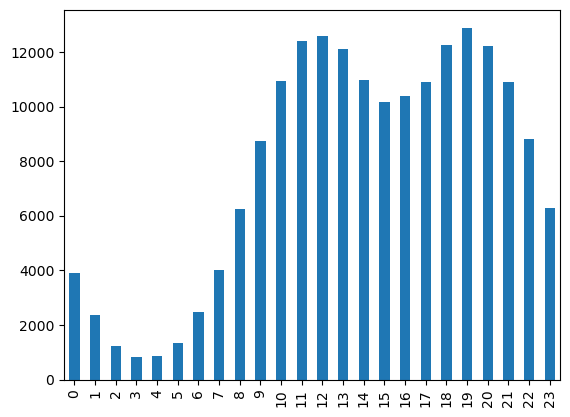

```python
hour_order_count.plot(kind="bar")
```

```python
## Which two products are most often bought together?
```

```python
final_df.sort_values('order_id')[['order_id', 'product']].reset_index().loc[100:200]
```

|  | index | order_id | product |
| --- | --- | --- | --- |
| 100 | 100 | 141332 | USB-C Charging Cable |
| 101 | 101 | 141333 | 27in FHD Monitor |
| 102 | 102 | 141334 | USB-C Charging Cable |
| 103 | 103 | 141335 | AAA Batteries (4-pack) |
| 104 | 104 | 141336 | iPhone |
| ... | ... | ... | ... |
| 196 | 196 | 141426 | Google Phone |
| 197 | 197 | 141427 | USB-C Charging Cable |
| 198 | 198 | 141428 | AA Batteries (4-pack) |
| 199 | 199 | 141429 | Apple Airpods Headphones |
| 200 | 200 | 141430 | 34in Ultrawide Monitor |

101 rows × 3 columns

```python
final_df.head()
```

|  | order_id | product | quantity_ordered | price_each | order_date | purchase_address | state_name | final_bill | City |
| --- | --- | --- | --- | --- | --- | --- | --- | --- | --- |
| 0 | 176558 | USB-C Charging Cable | 2 | 11.95 | 2019-04-19 08:46:00 | 917 1st St, Dallas, TX 75001 | TX | 23.90 | Dallas |
| 2 | 176559 | Bose SoundSport Headphones | 1 | 99.99 | 2019-04-07 22:30:00 | 682 Chestnut St, Boston, MA 02215 | MA | 99.99 | Boston |
| 3 | 176560 | Google Phone | 1 | 600.00 | 2019-04-12 14:38:00 | 669 Spruce St, Los Angeles, CA 90001 | CA | 600.00 | Los Angeles |
| 4 | 176560 | Wired Headphones | 1 | 11.99 | 2019-04-12 14:38:00 | 669 Spruce St, Los Angeles, CA 90001 | CA | 11.99 | Los Angeles |
| 5 | 176561 | Wired Headphones | 1 | 11.99 | 2019-04-30 09:27:00 | 333 8th St, Los Angeles, CA 90001 | CA | 11.99 | Los Angeles |

```python
# I want to find all the orders where the order id is repeated
```

```python
selected_df = final_df[final_df.duplicated(subset='order_id', keep=False)][['order_id', 'product']]
```

```python
selected_df.head(10)
```

|  | order_id | product |
| --- | --- | --- |
| 3 | 176560 | Google Phone |
| 4 | 176560 | Wired Headphones |
| 18 | 176574 | Google Phone |
| 19 | 176574 | USB-C Charging Cable |
| 30 | 176585 | Bose SoundSport Headphones |
| 31 | 176585 | Bose SoundSport Headphones |
| 32 | 176586 | AAA Batteries (4-pack) |
| 33 | 176586 | Google Phone |
| 119 | 176672 | Lightning Charging Cable |
| 120 | 176672 | USB-C Charging Cable |

```python
#selected_df.merge(selected_df, on="order_id", how="inner")
selected_df = \
pd.merge(left=selected_df,
        right=selected_df,
        left_on='order_id',
        right_on='order_id',
        how="inner",
        suffixes=('_left', '_right'))
```

```python
selected_df.head(10)
```

|  | order_id | product_left | product_right |
| --- | --- | --- | --- |
| 0 | 176560 | Google Phone | Google Phone |
| 1 | 176560 | Google Phone | Wired Headphones |
| 2 | 176560 | Wired Headphones | Google Phone |
| 3 | 176560 | Wired Headphones | Wired Headphones |
| 4 | 176574 | Google Phone | Google Phone |
| 5 | 176574 | Google Phone | USB-C Charging Cable |
| 6 | 176574 | USB-C Charging Cable | Google Phone |
| 7 | 176574 | USB-C Charging Cable | USB-C Charging Cable |
| 8 | 176585 | Bose SoundSport Headphones | Bose SoundSport Headphones |
| 9 | 176585 | Bose SoundSport Headphones | Bose SoundSport Headphones |

```python
# remove those rows where product_left == product_right
```

```python
selected_df = selected_df.loc[(selected_df['product_left'] != selected_df['product_right']), :]
```

```python
selected_df.order_id.value_counts().sort_values(ascending=False)
```

```
160873    20
277875    12
242936    12
295681    12
165665    12
          ..
249439     2
249444     2
249455     2
249468     2
259350     2
Name: order_id, Length: 6832, dtype: int64
```

```python
selected_df.loc[selected_df['order_id']== 160873    , :]
```

|  | order_id | product_left | product_right |
| --- | --- | --- | --- |
| 10666 | 160873 | iPhone | Lightning Charging Cable |
| 10667 | 160873 | iPhone | Apple Airpods Headphones |
| 10668 | 160873 | iPhone | Wired Headphones |
| 10669 | 160873 | iPhone | Google Phone |
| 10670 | 160873 | Lightning Charging Cable | iPhone |
| 10672 | 160873 | Lightning Charging Cable | Apple Airpods Headphones |
| 10673 | 160873 | Lightning Charging Cable | Wired Headphones |
| 10674 | 160873 | Lightning Charging Cable | Google Phone |
| 10675 | 160873 | Apple Airpods Headphones | iPhone |
| 10676 | 160873 | Apple Airpods Headphones | Lightning Charging Cable |
| 10678 | 160873 | Apple Airpods Headphones | Wired Headphones |
| 10679 | 160873 | Apple Airpods Headphones | Google Phone |
| 10680 | 160873 | Wired Headphones | iPhone |
| 10681 | 160873 | Wired Headphones | Lightning Charging Cable |
| 10682 | 160873 | Wired Headphones | Apple Airpods Headphones |
| 10684 | 160873 | Wired Headphones | Google Phone |
| 10685 | 160873 | Google Phone | iPhone |
| 10686 | 160873 | Google Phone | Lightning Charging Cable |
| 10687 | 160873 | Google Phone | Apple Airpods Headphones |
| 10688 | 160873 | Google Phone | Wired Headphones |

```python
selected_df = selected_df.loc[(selected_df['product_left'] != selected_df['product_right']), :]
```

```python
selected_df.head()
```

|  | order_id | product_left | product_right |
| --- | --- | --- | --- |
| 1 | 176560 | Google Phone | Wired Headphones |
| 2 | 176560 | Wired Headphones | Google Phone |
| 5 | 176574 | Google Phone | USB-C Charging Cable |
| 6 | 176574 | USB-C Charging Cable | Google Phone |
| 13 | 176586 | AAA Batteries (4-pack) | Google Phone |

```python
selected_df['product_combo']=selected_df['product_left'] +'|' +selected_df['product_right']
```

```python
selected_df.head()
```

|  | order_id | product_left | product_right | product_combo |
| --- | --- | --- | --- | --- |
| 1 | 176560 | Google Phone | Wired Headphones | Google Phone\|Wired Headphones |
| 2 | 176560 | Wired Headphones | Google Phone | Wired Headphones\|Google Phone |
| 5 | 176574 | Google Phone | USB-C Charging Cable | Google Phone\|USB-C Charging Cable |
| 6 | 176574 | USB-C Charging Cable | Google Phone | USB-C Charging Cable\|Google Phone |
| 13 | 176586 | AAA Batteries (4-pack) | Google Phone | AAA Batteries (4-pack)\|Google Phone |

```python
y = 'Google Phone|Wired Headphones'.split('|')
'|'.join(sorted(y))
```

```
'Google Phone|Wired Headphones'
```

```python
'|'.join(sorted('Wired Headphones|Google Phone'.split('|')))
```

```
'Google Phone|Wired Headphones'
```

```python
selected_df['product_combo'] = selected_df['product_combo'].apply(lambda pr_combo: '|'.join(sorted(pr_combo.split('|'))))
```

```python
selected_df.head()
```

|  | order_id | product_left | product_right | product_combo |
| --- | --- | --- | --- | --- |
| 1 | 176560 | Google Phone | Wired Headphones | Google Phone\|Wired Headphones |
| 2 | 176560 | Wired Headphones | Google Phone | Google Phone\|Wired Headphones |
| 5 | 176574 | Google Phone | USB-C Charging Cable | Google Phone\|USB-C Charging Cable |
| 6 | 176574 | USB-C Charging Cable | Google Phone | Google Phone\|USB-C Charging Cable |
| 13 | 176586 | AAA Batteries (4-pack) | Google Phone | AAA Batteries (4-pack)\|Google Phone |

```python
selected_df.drop_duplicates(subset=['order_id', 'product_combo'], keep="first", inplace=True)
```

```python
selected_df
```

|  | order_id | product_left | product_right | product_combo |
| --- | --- | --- | --- | --- |
| 1 | 176560 | Google Phone | Wired Headphones | Google Phone\|Wired Headphones |
| 5 | 176574 | Google Phone | USB-C Charging Cable | Google Phone\|USB-C Charging Cable |
| 13 | 176586 | AAA Batteries (4-pack) | Google Phone | AAA Batteries (4-pack)\|Google Phone |
| 17 | 176672 | Lightning Charging Cable | USB-C Charging Cable | Lightning Charging Cable\|USB-C Charging Cable |
| 21 | 176681 | Apple Airpods Headphones | ThinkPad Laptop | Apple Airpods Headphones\|ThinkPad Laptop |
| ... | ... | ... | ... | ... |
| 30441 | 259277 | iPhone | Wired Headphones | Wired Headphones\|iPhone |
| 30449 | 259297 | iPhone | Lightning Charging Cable | Lightning Charging Cable\|iPhone |
| 30458 | 259303 | 34in Ultrawide Monitor | AA Batteries (4-pack) | 34in Ultrawide Monitor\|AA Batteries (4-pack) |
| 30462 | 259314 | Wired Headphones | AAA Batteries (4-pack) | AAA Batteries (4-pack)\|Wired Headphones |
| 30466 | 259350 | Google Phone | USB-C Charging Cable | Google Phone\|USB-C Charging Cable |

7590 rows × 4 columns

```python
selected_df.groupby(['product_left',
                     'product_right'])['order_id'].count().sort_values(ascending=False).head(1)
```

```
product_left  product_right
iPhone        Lightning Charging Cable    1002
Name: order_id, dtype: int64
```

```python
selected_df.columns
```

```
Index(['order_id', 'product_left', 'product_right', 'product_combo'], dtype='object')
```

```python
answer = selected_df.loc[(selected_df['product_left']=='iPhone') & \
               (selected_df['product_right']=='Lightning Charging Cable'), 'order_id'].value_counts() > 1
```

```python
answer.sum()
```

```
0
```

```python
# planogram in retial
```

```python
list_1 = ['Google Phone', 'Wired Headphones']
list_2 = ['Wired Headphones', 'Google Phone']
```

```python
sorted(list_1)
```

```
['Google Phone', 'Wired Headphones']
```

```python
sorted(list_2)
```

```
['Google Phone', 'Wired Headphones']
```

```python
# BudLIGHT - 10000 13000 %30
# lIMEORITA  18000 1500
```

```python
# lets learn how to handle NULL values

import pandas as pd

ufo = pd.read_csv('http://bit.ly/uforeports')
ufo.head()
# NaN means blank value , or missing data or Null values
# NaN stands for Not A Number
```

|  | City | Colors Reported | Shape Reported | State | Time |
| --- | --- | --- | --- | --- | --- |
| 0 | Ithaca | NaN | TRIANGLE | NY | 6/1/1930 22:00 |
| 1 | Willingboro | NaN | OTHER | NJ | 6/30/1930 20:00 |
| 2 | Holyoke | NaN | OVAL | CO | 2/15/1931 14:00 |
| 3 | Abilene | NaN | DISK | KS | 6/1/1931 13:00 |
| 4 | New York Worlds Fair | NaN | LIGHT | NY | 4/18/1933 19:00 |

```python
ufo.isna().head()
```

|  | City | Colors Reported | Shape Reported | State | Time |
| --- | --- | --- | --- | --- | --- |
| 0 | False | True | False | False | False |
| 1 | False | True | False | False | False |
| 2 | False | True | False | False | False |
| 3 | False | True | False | False | False |
| 4 | False | True | False | False | False |

```python
ufo.isna().sum(axis=0)
```

```
City                  25
Colors Reported    15359
Shape Reported      2644
State                  0
Time                   0
dtype: int64
```

```python
ufo.shape
```

```
(18241, 5)
```

```python
ufo.dropna() # dropna will drop any record where even a single column has a NaN value
```

|  | City | Colors Reported | Shape Reported | State | Time |
| --- | --- | --- | --- | --- | --- |
| 12 | Belton | RED | SPHERE | SC | 6/30/1939 20:00 |
| 19 | Bering Sea | RED | OTHER | AK | 4/30/1943 23:00 |
| 36 | Portsmouth | RED | FORMATION | VA | 7/10/1945 1:30 |
| 44 | Blairsden | GREEN | SPHERE | CA | 6/30/1946 19:00 |
| 82 | San Jose | BLUE | CHEVRON | CA | 7/15/1947 21:00 |
| ... | ... | ... | ... | ... | ... |
| 18213 | Pasadena | GREEN | FIREBALL | CA | 12/28/2000 19:10 |
| 18216 | Garden Grove | ORANGE | LIGHT | CA | 12/29/2000 16:10 |
| 18220 | Shasta Lake | BLUE | DISK | CA | 12/29/2000 20:30 |
| 18233 | Anchorage | RED | VARIOUS | AK | 12/31/2000 21:00 |
| 18239 | Eagle River | RED | LIGHT | WI | 12/31/2000 23:45 |

2486 rows × 5 columns

```python
ufo.dropna().shape
```

```
(2486, 5)
```

```python
ufo.dropna(how="any", inplace=False) # In a ROW if any columns have NaN value then drop the entire row
```

|  | City | Colors Reported | Shape Reported | State | Time |
| --- | --- | --- | --- | --- | --- |
| 12 | Belton | RED | SPHERE | SC | 6/30/1939 20:00 |
| 19 | Bering Sea | RED | OTHER | AK | 4/30/1943 23:00 |
| 36 | Portsmouth | RED | FORMATION | VA | 7/10/1945 1:30 |
| 44 | Blairsden | GREEN | SPHERE | CA | 6/30/1946 19:00 |
| 82 | San Jose | BLUE | CHEVRON | CA | 7/15/1947 21:00 |
| ... | ... | ... | ... | ... | ... |
| 18213 | Pasadena | GREEN | FIREBALL | CA | 12/28/2000 19:10 |
| 18216 | Garden Grove | ORANGE | LIGHT | CA | 12/29/2000 16:10 |
| 18220 | Shasta Lake | BLUE | DISK | CA | 12/29/2000 20:30 |
| 18233 | Anchorage | RED | VARIOUS | AK | 12/31/2000 21:00 |
| 18239 | Eagle River | RED | LIGHT | WI | 12/31/2000 23:45 |

2486 rows × 5 columns

```python
ufo.dropna(how="all").shape
```

```
(18241, 5)
```

```python
ufo.isna().sum()
```

```
City                  25
Colors Reported    15359
Shape Reported      2644
State                  0
Time                   0
dtype: int64
```

```python
# drop a row(record) from the UFO dataframe when either of the two column have a NaN value
# if any of the column has NaN value the the row will be dropped
df_clean = ufo.dropna(subset=['City', 'Shape Reported'], how = "any", inplace=False)
```

```python
df_clean.isna().sum()
```

```
City                   0
Colors Reported    13090
Shape Reported         0
State                  0
Time                   0
dtype: int64
```

```python
df_clean.shape
```

```
(15576, 5)
```

```python
# drop a row(record) from the UFO dataframe when N of both of the two column have a NaN value
# if both of the column has NaN value the the row will be dropped
df_clean = ufo.dropna(subset=['City', 'Shape Reported'], how = "all", inplace=False)
```

```python
df_clean.isna().sum()
```

```
City                  21
Colors Reported    15356
Shape Reported      2640
State                  0
Time                   0
dtype: int64
```

```python
ufo.loc[(ufo['City'].isna()==True) & \
       (ufo['Shape Reported'].isna()== True), :]
```

|  | City | Colors Reported | Shape Reported | State | Time |
| --- | --- | --- | --- | --- | --- |
| 21 | NaN | NaN | NaN | LA | 8/15/1943 0:00 |
| 2013 | NaN | NaN | NaN | NH | 8/1/1970 9:30 |
| 5269 | NaN | NaN | NaN | AZ | 6/30/1985 21:30 |
| 16054 | NaN | GREEN | NaN | FL | 3/11/2000 3:30 |

```python
ufo.dropna(subset = ['City', 'Shape Reported'], how="all", inplace=False).shape
```

```
(18237, 5)
```

```python
ufo.shape
```

```
(18241, 5)
```

```python
ufo['Colors Reported'].value_counts(dropna=False)
```

```
NaN                       15359
RED                         780
GREEN                       531
ORANGE                      528
BLUE                        450
YELLOW                      169
RED GREEN                    89
RED BLUE                     78
RED ORANGE                   44
GREEN BLUE                   34
RED GREEN BLUE               33
ORANGE YELLOW                26
RED YELLOW                   25
ORANGE GREEN                 23
YELLOW GREEN                 17
ORANGE BLUE                  10
RED YELLOW GREEN              9
YELLOW BLUE                   6
YELLOW GREEN BLUE             5
ORANGE GREEN BLUE             5
RED YELLOW GREEN BLUE         4
RED ORANGE YELLOW             4
RED YELLOW BLUE               3
RED ORANGE GREEN              3
RED ORANGE BLUE               3
RED ORANGE YELLOW BLUE        1
ORANGE YELLOW GREEN           1
ORANGE YELLOW BLUE            1
Name: Colors Reported, dtype: int64
```

```python
ufo['City'].value_counts(dropna=False)[ufo['City'].value_counts(dropna=False) == 25]
```

[output not shown]

```python
import numpy as np
np.nan in ufo['City'].value_counts(dropna=True)
```

```
False
```

```python
'Cincinnati' in ufo['City'].value_counts(dropna=True)
```

```
True
```

```python
np.nan in ufo['City'].value_counts(dropna=False)
```

```
True
```

```python
ufo['City'].value_counts(dropna=False)[np.nan]
```

```
25
```

```python
# is the city 'Houston' one of the cities in the index
'Houston' in ufo['City'].value_counts(dropna=False)
```

```
True
```

```python
np.nan in ufo['City'].value_counts(dropna=False)
```

```
True
```

```python
ufo['City'].value_counts(dropna=False)['Cincinnati']
```

```
25
```

```python
ufo.isna().sum()
```

```
City                  25
Colors Reported    15359
Shape Reported      2644
State                  0
Time                   0
dtype: int64
```

```python
# lets learn how to work with Data AND time in Pandas

import pandas as pd
ufo = pd.read_csv('http://bit.ly/uforeports')
ufo.head()
```

|  | City | Colors Reported | Shape Reported | State | Time |
| --- | --- | --- | --- | --- | --- |
| 0 | Ithaca | NaN | TRIANGLE | NY | 6/1/1930 22:00 |
| 1 | Willingboro | NaN | OTHER | NJ | 6/30/1930 20:00 |
| 2 | Holyoke | NaN | OVAL | CO | 2/15/1931 14:00 |
| 3 | Abilene | NaN | DISK | KS | 6/1/1931 13:00 |
| 4 | New York Worlds Fair | NaN | LIGHT | NY | 4/18/1933 19:00 |

```python
ufo.dtypes
```

```
City               object
Colors Reported    object
Shape Reported     object
State              object
Time               object
dtype: object
```

```python
ufo['Time'] = pd.to_datetime(ufo['Time'], format = '%m/%d/%Y %H:%M')
```

```python
ufo.dtypes
```

```
City                       object
Colors Reported            object
Shape Reported             object
State                      object
Time               datetime64[ns]
dtype: object
```

```python
ufo['Time'].dt.day_name()
```

```
0         Sunday
1         Monday
2         Sunday
3         Monday
4        Tuesday
          ...
18236     Sunday
18237     Sunday
18238     Sunday
18239     Sunday
18240     Sunday
Name: Time, Length: 18241, dtype: object
```

```python
# %m is numeric month
# %d is numeric day
# %Y year in YYYYY
# %H is hour
# %M is minutes
pd.to_datetime('6/1/1930 22:00', format='%m/%d/%Y %H:%M')
```

```
Timestamp('1930-06-01 22:00:00')
```

```python
pd.to_datetime(final_df['order_date'], format = '%m/%d/%y %H:%M')
```

```
0       2019-04-19 08:46:00
2       2019-04-07 22:30:00
3       2019-04-12 14:38:00
4       2019-04-12 14:38:00
5       2019-04-30 09:27:00
                ...
11681   2019-09-17 20:56:00
11682   2019-09-01 16:00:00
11683   2019-09-23 07:39:00
11684   2019-09-19 17:30:00
11685   2019-09-30 00:18:00
Name: order_date, Length: 185950, dtype: datetime64[ns]
```

```python
### generate dummy data
```

```python
import random
```

```python
random.random()
```

```
0.694659234786593
```

```python
random.randint(10, 15)
```

```
15
```

```python
male_first_names = ['Rakesh', 'Shubhum', 'Shekhar', 'Unmesh', 'Puru',
              'Joy', 'Shouvik', 'Adithya', 'Bikram',  'Rupu', 'Ronty',
               'Shrisendu', 'Nattoo', 'Rohit',
               'Samar', 'Pankaj', 'Ashish', 'Andy', 'Anubhav', 'Gurpreet', 'Suhas',
                   'Vijay']

female_first_names = ['Simran', 'Sreelekha', 'Sonali', 'Nupur',
                      'Banishree', 'Rinka', 'Aprajita', 'Aparna', 'Sushmita', 'Swapna',
                      'Anjani', 'Radhika', 'Chetana', 'Chandrima', 'Geeta', 'Reshma', 'Pooja']


last_names = ['Simran', 'Sreelekha', 'Rakesh', 'Shubhum', 'Shekhar', 'Unmesh', 'Puru',
              'Joy', 'Shouvik', 'Adithya', 'Bikram', 'Sonali', 'Nupur', 'Rupu', 'Ronty',
               'Banishree', 'Rinka', 'Aprajita', 'Aparna', 'Shrisendu', 'Nattoo', 'Rohit',
               'Samar', 'Pankaj']


def get_full_names(number_of_names = 50):
    full_names = []
    gender = None
    while len(full_names) < number_of_names :
        gender = None
        if random.choice(['Male', 'Female']) == 'Male':
            first_name = random.choice(male_first_names)
            gender = 'Male'
        else:
            first_name = random.choice(female_first_names)
            gender = 'Female'

        last_name  = random.choice(last_names)

        if f'{first_name} {last_name}' not in full_names:
            value = (f'{first_name} {last_name}', gender)
            full_names.append(value)

    return full_names
```

```python
get_full_names(number_of_names = 100)
```

```
[('Anubhav Shekhar', 'Male'),
 ('Pankaj Joy', 'Male'),
 ('Bikram Shubhum', 'Male'),
 ('Pooja Sonali', 'Female'),
 ('Radhika Aparna', 'Female'),
 ('Reshma Aparna', 'Female'),
 ('Chetana Rinka', 'Female'),
 ('Sreelekha Bikram', 'Female'),
 ('Pankaj Unmesh', 'Male'),
 ('Ashish Rohit', 'Male'),
 ('Shekhar Aparna', 'Male'),
 ('Aparna Bikram', 'Female'),
 ('Pankaj Aprajita', 'Male'),
 ('Joy Shouvik', 'Male'),
 ('Swapna Rohit', 'Female'),
 ('Suhas Shouvik', 'Male'),
 ('Rakesh Shrisendu', 'Male'),
 ('Chandrima Aprajita', 'Female'),
 ('Swapna Shubhum', 'Female'),
 ('Geeta Joy', 'Female'),
 ('Suhas Simran', 'Male'),
 ('Rohit Sonali', 'Male'),
 ('Anjani Unmesh', 'Female'),
 ('Anjani Bikram', 'Female'),
 ('Banishree Aprajita', 'Female'),
 ('Banishree Banishree', 'Female'),
 ('Sreelekha Unmesh', 'Female'),
 ('Vijay Aprajita', 'Male'),
 ('Reshma Sreelekha', 'Female'),
 ('Adithya Ronty', 'Male'),
 ('Sushmita Shrisendu', 'Female'),
 ('Anubhav Shekhar', 'Male'),
 ('Sushmita Shekhar', 'Female'),
 ('Joy Unmesh', 'Male'),
 ('Rupu Rupu', 'Male'),
 ('Ronty Shrisendu', 'Male'),
 ('Aparna Joy', 'Female'),
 ('Pooja Aprajita', 'Female'),
 ('Sushmita Rohit', 'Female'),
 ('Banishree Nupur', 'Female'),
```

[output cut: 45 more lines]

```
 ('Chetana Samar', 'Female'),
 ('Reshma Joy', 'Female'),
 ('Gurpreet Puru', 'Male'),
 ('Adithya Shouvik', 'Male'),
 ('Gurpreet Unmesh', 'Male'),
 ('Rohit Unmesh', 'Male'),
 ('Pankaj Puru', 'Male'),
 ('Rakesh Rinka', 'Male'),
 ('Sonali Rakesh', 'Female'),
 ('Joy Adithya', 'Male'),
 ('Rohit Nattoo', 'Male'),
 ('Chetana Shubhum', 'Female'),
 ('Sonali Aparna', 'Female'),
 ('Chetana Bikram', 'Female'),
 ('Shouvik Samar', 'Male')]
```

```python
full_names = []
while len(full_names) < 50:
    full_name = random.choice(first_names)+ ' '+ random.choice(last_names)
    if full_name not in full_names:
        full_names.append(full_name)
```

CREATE TABLE friends_info( friend_id INT PRIMARY KEY IDENTITY(1,1) ,friend_name VARCHAR(100) NOT NULL UNIQUE ,zip_code CHAR(6) NOT NULL ,salary DECIMAL(10, 2) NOT NULL CHECK( salary > 9999) ); ### Create the SELECT statement

### F String

```python
name = 'Rakesh'
college = 'Presidency College'
location = 'Behrampur'

message = name + ' studies in ' + college + ', ' + location + '.'
print(message)
```

```
Rakesh studies in Presidency College, Behrampur.
```

```python
message = f'{name} studies in {college}, {location}.'
```

```python
name = 'Shubhum'
college = 'Presidency College'
location = 'Cuttack'

message = f'{name} studies in {college}, {location}.'
print(message)
```

```
Shubhum studies in Presidency College, Cuttack.
```

CREATE TABLE friends_info( friend_id INT PRIMARY KEY IDENTITY(1,1) ,friend_name VARCHAR(100) NOT NULL UNIQUE ,friend_dob DATE NOT NULL ,gender VARCHAR(8) NOT NULL CHECK(gender in ('Male', 'Female')) ,zip_code CHAR(6) NOT NULL ,salary DECIMAL(10, 2) NOT NULL CHECK (salary > 9999.99) ); ### Create the SELECT statement

```python
def get_year():
    return random.choice(list(range(1990, 2005)))

def get_month():
    return random.choice(['01', '02', '03', '04', '05', '06'])

def get_day():
    return random.choice(list(range(10, 27)))

def get_dob():
    return f"'{get_year()}-{get_month()}-{get_day()}'"



# zip codes have 5 character and zip codes do not start with 0.
def get_zip_code():
    return str(random.choice(range(100000, 600002)))



def get_gender():
    '''function to get a random gender between Male and Female'''
    return random.choice(['Male', 'Female'])


def get_salary(start_val = 10000, max_val = 60000):
    return float(random.choice(range(start_val, max_val)))

def get_location():
    locations = {
        "Mumbai": "Maharashtra",
            "Delhi": "Delhi",
            "Bangalore": "Karnataka",
            "Kolkata": "West Bengal",
            "Chennai": "Tamil Nadu",
            "Hyderabad": "Telangana",
            "Pune": "Maharashtra",
            "Jaipur": "Rajasthan",
            "Ahmedabad": "Gujarat",
            "Surat": "Gujarat",
            "Lucknow": "Uttar Pradesh",
            "Kanpur": "Uttar Pradesh",
            "Patna": "Bihar",
            "Ranchi": "Jharkhand"
    }
    place = random.choice(list(locations.keys()))
    state = locations[place]
    return (place, state)

def get_complete_address(tup_input):
    return f'{tup_input[0]}, {tup_input[1]}'
```

```python
get_location()
```

```
('Surat', 'Gujarat')
```

```python
get_gender()
```

```
'Female'
```

```python
print(get_dob())
```

```
'2000-01-16'
```

```python
query = \
'INSERT INTO friends_info(friend_name, friend_dob, gender, zip_code, salary, place, state_name) VALUES('
```

```python
#print(query)

full_names = get_full_names(100)
for name, gender in full_names:
    place, state = get_location()
    print(f"{query}'{name}',{get_dob()}, \
    '{gender}', '{get_zip_code()}', {get_salary(max_val=100000)}, \
    '{place}', '{state}');")
```

```
INSERT INTO friends_info(friend_name, friend_dob, gender, zip_code, salary, place, state_name) VALUES('Chetana Nupur','1999-06-19',     'Female', '536810', 79873.0,     'Delhi', 'Delhi');
INSERT INTO friends_info(friend_name, friend_dob, gender, zip_code, salary, place, state_name) VALUES('Bikram Samar','2004-04-26',     'Male', '428850', 97426.0,     'Kolkata', 'West Bengal');
INSERT INTO friends_info(friend_name, friend_dob, gender, zip_code, salary, place, state_name) VALUES('Reshma Rinka','1998-03-11',     'Female', '484595', 23428.0,     'Ranchi', 'Jharkhand');
INSERT INTO friends_info(friend_name, friend_dob, gender, zip_code, salary, place, state_name) VALUES('Anjani Rakesh','2004-04-26',     'Female', '106658', 24494.0,     'Mumbai', 'Maharashtra');
INSERT INTO friends_info(friend_name, friend_dob, gender, zip_code, salary, place, state_name) VALUES('Shouvik Puru','2000-03-22',     'Male', '475944', 29361.0,     'Kolkata', 'West Bengal');
INSERT INTO friends_info(friend_name, friend_dob, gender, zip_code, salary, place, state_name) VALUES('Rinka Pankaj','2003-03-16',     'Female', '224646', 93923.0,     'Patna', 'Bihar');
INSERT INTO friends_info(friend_name, friend_dob, gender, zip_code, salary, place, state_name) VALUES('Banishree Rupu','2002-06-18',     'Female', '414979', 77039.0,     'Kolkata', 'West Bengal');
INSERT INTO friends_info(friend_name, friend_dob, gender, zip_code, salary, place, state_name) VALUES('Aprajita Adithya','2004-04-23',     'Female', '564088', 66901.0,     'Bangalore', 'Karnataka');
INSERT INTO friends_info(friend_name, friend_dob, gender, zip_code, salary, place, state_name) VALUES('Aparna Shrisendu','1992-06-21',     'Female', '190899', 96883.0,     'Chennai', 'Tamil Nadu');
INSERT INTO friends_info(friend_name, friend_dob, gender, zip_code, salary, place, state_name) VALUES('Chandrima Banishree','1998-04-15',     'Female', '545073', 20270.0,     'Mumbai', 'Maharashtra');
INSERT INTO friends_info(friend_name, friend_dob, gender, zip_code, salary, place, state_name) VALUES('Simran Rakesh','1991-05-12',     'Female', '325331', 59882.0,     'Surat', 'Gujarat');
INSERT INTO friends_info(friend_name, friend_dob, gender, zip_code, salary, place, state_name) VALUES('Rohit Rinka','2002-05-20',     'Male', '452092', 58094.0,     'Hyderabad', 'Telangana');
INSERT INTO friends_info(friend_name, friend_dob, gender, zip_code, salary, place, state_name) VALUES('Sushmita Rinka','1997-04-23',     'Female', '202550', 66995.0,     'Kanpur', 'Uttar Pradesh');
INSERT INTO friends_info(friend_name, friend_dob, gender, zip_code, salary, place, state_name) VALUES('Pankaj Puru','1994-05-26',     'Male', '499160', 62638.0,     'Kanpur', 'Uttar Pradesh');
INSERT INTO friends_info(friend_name, friend_dob, gender, zip_code, salary, place, state_name) VALUES('Suhas Aparna','2003-05-22',     'Male', '146943', 61656.0,     'Chennai', 'Tamil Nadu');
INSERT INTO friends_info(friend_name, friend_dob, gender, zip_code, salary, place, state_name) VALUES('Rinka Adithya','1994-01-13',     'Female', '418922', 16578.0,     'Lucknow', 'Uttar Pradesh');
INSERT INTO friends_info(friend_name, friend_dob, gender, zip_code, salary, place, state_name) VALUES('Gurpreet Nattoo','2000-01-23',     'Male', '553962', 30223.0,     'Jaipur', 'Rajasthan');
INSERT INTO friends_info(friend_name, friend_dob, gender, zip_code, salary, place, state_name) VALUES('Aparna Shouvik','1998-05-22',     'Female', '421511', 61827.0,     'Pune', 'Maharashtra');
INSERT INTO friends_info(friend_name, friend_dob, gender, zip_code, salary, place, state_name) VALUES('Rohit Shouvik','1990-02-12',     'Male', '361859', 34466.0,     'Hyderabad', 'Telangana');
INSERT INTO friends_info(friend_name, friend_dob, gender, zip_code, salary, place, state_name) VALUES('Reshma Pankaj','1999-05-14',     'Female', '448898', 83100.0,     'Ranchi', 'Jharkhand');
INSERT INTO friends_info(friend_name, friend_dob, gender, zip_code, salary, place, state_name) VALUES('Unmesh Unmesh','2001-03-20',     'Male', '422964', 89240.0,     'Lucknow', 'Uttar Pradesh');
INSERT INTO friends_info(friend_name, friend_dob, gender, zip_code, salary, place, state_name) VALUES('Samar Unmesh','1991-04-23',     'Male', '423107', 85740.0,     'Pune', 'Maharashtra');
INSERT INTO friends_info(friend_name, friend_dob, gender, zip_code, salary, place, state_name) VALUES('Gurpreet Pankaj','1999-06-25',     'Male', '498143', 44971.0,     'Patna', 'Bihar');
INSERT INTO friends_info(friend_name, friend_dob, gender, zip_code, salary, place, state_name) VALUES('Aparna Samar','1997-04-24',     'Female', '471128', 53770.0,     'Pune', 'Maharashtra');
INSERT INTO friends_info(friend_name, friend_dob, gender, zip_code, salary, place, state_name) VALUES('Ronty Rinka','2003-05-16',     'Male', '445595', 58919.0,     'Pune', 'Maharashtra');
INSERT INTO friends_info(friend_name, friend_dob, gender, zip_code, salary, place, state_name) VALUES('Geeta Pankaj','1998-01-23',     'Female', '596054', 51720.0,     'Hyderabad', 'Telangana');
```

[output cut: 74 more lines]

```python
for x in enumerate(full_names):
    print(x, x[0], x[-1])
    dummy_name = x[-1]
    # unpack the tuple
    name, gender = dummy_name
    print(dummy_name, name, gender, type(dummy_name))
    print('************')
```

```
(0, ('Chetana Nupur', 'Female')) 0 ('Chetana Nupur', 'Female')
('Chetana Nupur', 'Female') Chetana Nupur Female <class 'tuple'>
************
(1, ('Bikram Samar', 'Male')) 1 ('Bikram Samar', 'Male')
('Bikram Samar', 'Male') Bikram Samar Male <class 'tuple'>
************
(2, ('Reshma Rinka', 'Female')) 2 ('Reshma Rinka', 'Female')
('Reshma Rinka', 'Female') Reshma Rinka Female <class 'tuple'>
************
(3, ('Anjani Rakesh', 'Female')) 3 ('Anjani Rakesh', 'Female')
('Anjani Rakesh', 'Female') Anjani Rakesh Female <class 'tuple'>
************
(4, ('Shouvik Puru', 'Male')) 4 ('Shouvik Puru', 'Male')
('Shouvik Puru', 'Male') Shouvik Puru Male <class 'tuple'>
************
(5, ('Rinka Pankaj', 'Female')) 5 ('Rinka Pankaj', 'Female')
('Rinka Pankaj', 'Female') Rinka Pankaj Female <class 'tuple'>
************
(6, ('Banishree Rupu', 'Female')) 6 ('Banishree Rupu', 'Female')
('Banishree Rupu', 'Female') Banishree Rupu Female <class 'tuple'>
************
(7, ('Aprajita Adithya', 'Female')) 7 ('Aprajita Adithya', 'Female')
('Aprajita Adithya', 'Female') Aprajita Adithya Female <class 'tuple'>
************
(8, ('Aparna Shrisendu', 'Female')) 8 ('Aparna Shrisendu', 'Female')
('Aparna Shrisendu', 'Female') Aparna Shrisendu Female <class 'tuple'>
************
(9, ('Chandrima Banishree', 'Female')) 9 ('Chandrima Banishree', 'Female')
('Chandrima Banishree', 'Female') Chandrima Banishree Female <class 'tuple'>
************
(10, ('Simran Rakesh', 'Female')) 10 ('Simran Rakesh', 'Female')
('Simran Rakesh', 'Female') Simran Rakesh Female <class 'tuple'>
************
(11, ('Rohit Rinka', 'Male')) 11 ('Rohit Rinka', 'Male')
('Rohit Rinka', 'Male') Rohit Rinka Male <class 'tuple'>
************
(12, ('Sushmita Rinka', 'Female')) 12 ('Sushmita Rinka', 'Female')
('Sushmita Rinka', 'Female') Sushmita Rinka Female <class 'tuple'>
************
(13, ('Pankaj Puru', 'Male')) 13 ('Pankaj Puru', 'Male')
```

[output cut: 245 more lines]

```
(95, ('Shubhum Shrisendu', 'Male')) 95 ('Shubhum Shrisendu', 'Male')
('Shubhum Shrisendu', 'Male') Shubhum Shrisendu Male <class 'tuple'>
************
(96, ('Swapna Samar', 'Female')) 96 ('Swapna Samar', 'Female')
('Swapna Samar', 'Female') Swapna Samar Female <class 'tuple'>
************
(97, ('Sushmita Unmesh', 'Female')) 97 ('Sushmita Unmesh', 'Female')
('Sushmita Unmesh', 'Female') Sushmita Unmesh Female <class 'tuple'>
************
(98, ('Anjani Bikram', 'Female')) 98 ('Anjani Bikram', 'Female')
('Anjani Bikram', 'Female') Anjani Bikram Female <class 'tuple'>
************
(99, ('Rinka Aprajita', 'Female')) 99 ('Rinka Aprajita', 'Female')
('Rinka Aprajita', 'Female') Rinka Aprajita Female <class 'tuple'>
************
```

## Generate Pandas DataFrame Randomly.

```python
# fist_name, last_name, age, location
import pandas as pd

full_names = get_full_names(100)

names = []
gender = []
for n , g in full_names:
    names.append(n)
    gender.append(g)
print(len(first_names), len(last_names))


# in the dictionary the keys will be column  names
people_d = {'person_name':n, 'gender':gender,
           'location':[get_complete_address(get_location())for i  in range(100)]}

friends_df = pd.DataFrame(people_d)
friends_df
```

[output not shown]

|  | person_name | gender | location |
| --- | --- | --- | --- |
| 0 | Rinka Kumar | Male | Ranchi, Jharkhand |
| 1 | Rinka Kumar | Female | Ranchi, Jharkhand |
| 2 | Rinka Kumar | Male | Jaipur, Rajasthan |
| 3 | Rinka Kumar | Female | Hyderabad, Telangana |
| 4 | Rinka Kumar | Male | Kanpur, Uttar Pradesh |
| ... | ... | ... | ... |
| 95 | Rinka Kumar | Male | Kanpur, Uttar Pradesh |
| 96 | Rinka Kumar | Male | Chennai, Tamil Nadu |
| 97 | Rinka Kumar | Male | Delhi, Delhi |
| 98 | Rinka Kumar | Male | Surat, Gujarat |
| 99 | Rinka Kumar | Female | Pune, Maharashtra |

100 rows × 3 columns

```python
# I will teach you how to write this code as part of a module
def get_dataframe(number_of_rows = 100,
                  duplicate=False,
                  nullable=False):
    names = []
    genders = []
    for n , g in full_names:
        names.append(n)
        genders.append(g)

    df = \
    pd.DataFrame({'person_name':names,
                  'gender':genders,
                  'salary':[get_salary() for x in  range(100)],
                  'location': \
                  [get_complete_address(get_location())for i  in range(100)],
                  'zip_code':[get_zip_code() for i in range(100)]})

    return df
```

```python
df = get_dataframe()
```

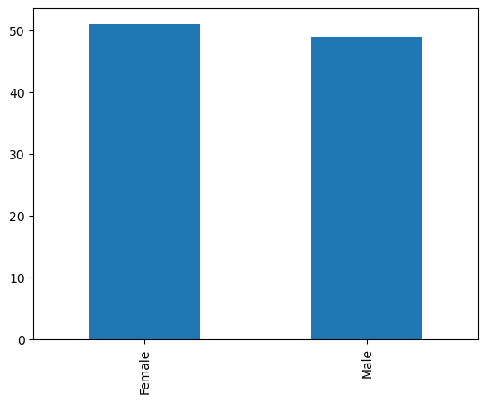

```python
df['gender'].value_counts(dropna=False).plot(kind='bar')
```

```python
df['state_name'] = df['location'].apply(lambda x : x.split(', ')[-1].strip())
```

```python
df['state_name'].value_counts(dropna=False).plot(kind='bar')
```

[output not shown]

```python
df
```

[output not shown]

100 rows × 5 columns

```python
# average salary for people from Delhi

max_sal = df.loc[df['location'].str.contains('Karnataka'), 'salary'].max()
print(max_sal)
```

[output not shown]

```python
df.loc[(df['location'].str.contains('Karnataka')) & \
      (df['salary']== max_sal), :]
```

[output not shown]

```python
# How to identify duplicates
data = {
    "friend_name":['Rakesh', 'Simran', 'Sreelekha', 'Shubhum', 'Rakesh'],
    "friend_age":[22, 21, 22, 21, 22]
}
```

```python
data.keys()
```

```
dict_keys(['friend_name', 'friend_age'])
```

```python
data['friend_name'] # friend_name is the key and I am going to use the friend name to get the list
```

```
['Rakesh', 'Simran', 'Sreelekha', 'Shubhum', 'Rakesh']
```

```python
data['friend_age']
```

```
[22, 21, 22, 21, 22]
```

```python
friend_df = pd.DataFrame(data)
```

```python
type(friend_df)
```

```
pandas.core.frame.DataFrame
```

```python
friend_df
```

|  | friend_name | friend_age |
| --- | --- | --- |
| 0 | Rakesh | 22 |
| 1 | Simran | 21 |
| 2 | Sreelekha | 22 |
| 3 | Shubhum | 21 |
| 4 | Rakesh | 22 |

```python
friend_df[friend_df.duplicated()]
```

|  | friend_name | friend_age |
| --- | --- | --- |
| 4 | Rakesh | 22 |

```python
friend_df[friend_df.duplicated(keep="first")]
```

|  | friend_name | friend_age |
| --- | --- | --- |
| 4 | Rakesh | 22 |

```python
friend_df[friend_df.duplicated(keep="last")]
```

|  | friend_name | friend_age |
| --- | --- | --- |
| 0 | Rakesh | 22 |

```python
friend_df[friend_df.duplicated(keep=True)] # the parameter keep can have only 3 values
# keep = "first"
# keep = "last"
# keep = First
```

[output not shown]

```python
# How to identify duplicates
data = {
    "friend_name":['Rakesh', 'Simran', 'Sreelekha', 'Shubhum', 'Rakesh'],
    "location":["Cuttack", "Bhubhaneshwar", "Behrampur", "Dhankenal", "Cuttack"],
    "friend_age":[22, 21, 22, 21, 23]
}

df = pd.DataFrame(data)
df
```

|  | friend_name | location | friend_age |
| --- | --- | --- | --- |
| 0 | Rakesh | Cuttack | 22 |
| 1 | Simran | Bhubhaneshwar | 21 |
| 2 | Sreelekha | Behrampur | 22 |
| 3 | Shubhum | Dhankenal | 21 |
| 4 | Rakesh | Cuttack | 23 |

```python
# This is the default behavior when finding duplicates
# use all the column names in the dataframe to identify a duplicated
# the default value of the parameter keep = "first"
df.duplicated(subset=['friend_name', 'location', 'friend_age'], keep="first")
```

```
0    False
1    False
2    False
3    False
4    False
dtype: bool
```

```python
df[df.duplicated(subset=['friend_name', 'location'], keep=False)]
```

|  | friend_name | location | friend_age |
| --- | --- | --- | --- |
| 0 | Rakesh | Cuttack | 22 |
| 4 | Rakesh | Cuttack | 23 |

```python
friends = ['Sreelekha', 'Rakesh', 'Simran', 'Shubhum', 'Unmesh', 'Shekhar']
```

```python
'|'.join(friends)
```

```
'Sreelekha|Rakesh|Simran|Shubhum|Unmesh|Shekhar'
```

```python
'-|-'.join(friends)
```

```
'Sreelekha-|-Rakesh-|-Simran-|-Shubhum-|-Unmesh-|-Shekhar'
```

```python
','.join(friends)
```

```
'Sreelekha,Rakesh,Simran,Shubhum,Unmesh,Shekhar'
```

```python
# 7:30 10:00 pm

# 6
```

```python
# json
```